# Documentos Interactivos

01 de junio, 2017

## Contenido

## Contenido

- Introducción
- Documentos interactivos
- Crear un documento interactivo
- Widgets: Inputs & Outputs
- Ejemplos

## Introducción

## Introducción

### Documentos interactivos

En la sesión anterior se ha introducido la creación de documentos mediante el entorno *RMarkdown* ([R Markdown](http://rmarkdown.rstudio.com/))

Este entorno nos ofrece un gran abanico de posibilidades en la escritura (lenguaje) y la salida (Word, Pdf,…), pero en todos los casos produce **documentos estáticos**.

Los **documentos interactivos** permiten al *lector (usuario)* **interactuar** con el documento modificando gráficos, tablas de resultados o cualquier contenido que haya sido diseñado en la creación del documento para poder ser modificado ([R Markdown-Documentos Interactivos](http://rmarkdown.rstudio.com/lesson-14.html)).

## Introducción

### Reproducibilidad

**¿Cómo ayudan este tipo de documentos en la reproducibilidad?**

- Se trata de un tipo de documentos *RMarkdown*, por lo que las mismas ideas expuestas en la sesión de *RMarkdown* son aplicables a este tipo de documentos.
- Además, como mostraremos en esta sesión, la introducción de elementos que los hacen **dinámicos** proporciona gran potencia para resumir en un espacio reducido gran cantidad de información.
- Más allá de la reproducibilidad estricta, es una **herramienta útil** para **compartir** todos los resultados asociados a una investigación y que, por ejemplo, no han sido mostrados en un paper por disponer en general de espacio muy reducido. *Por ejemplo, resultados de la apliación de un modelo a diferentes contextos (Disease Mapping en multitud de enfermedades diferentes)*

## Introducción

### Utilidad

**¿Por qué documentos interactivos?… *Mi experiencia***

- **Réplicas** de análisis estadísticos de estimación de incidencia, estimación de tendencias, estimación de supervivencia, etc,….para diferentes combinaciones de grupos tumorales.
- **RMarkdown** me permitía programar un **análisis completo** y replicarlo para tantas combinaciones de grupos tumorales como deseara de forma muy eficiente. Además podía devolver un documento **Word** que mis compañeros epidemiólogos podían manejar perfectamente para publicar resultados.
- Pero…tal y como pensábamos en incorporar más y más resultados para cada grupo tumoral, el documento final crecía y crecía….llegando a tener **cerca de 1000 páginas**!!!

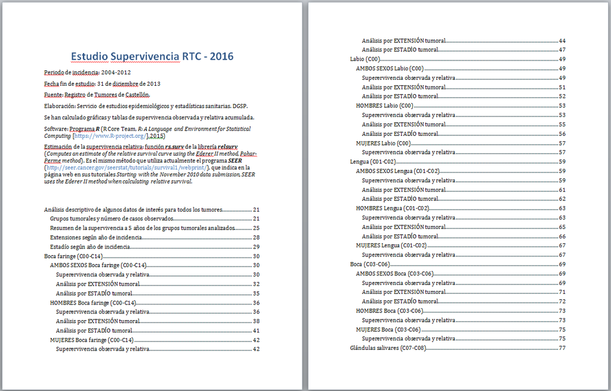

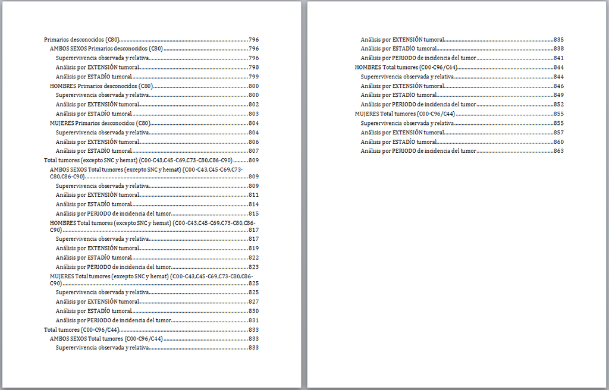

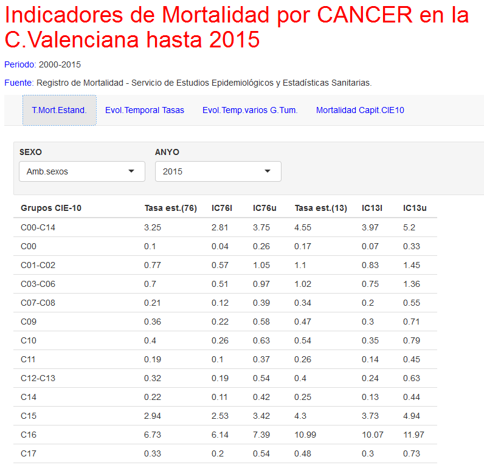

## Introducción

### Utilidad

**¿Por qué documentos interactivos?… *Investigación: herramienta propia***

En ocasiones aplicamos **diferentes modelos** a **diferentes bancos de datos** y obtenemos **multitud de resultados** en cada ocasión….

Este tipo de herramientas permiten mostrar los resultados de forma que su consulta nos resulte útil en la exploración de los mismos.

## Introducción

### Utilidad

**¿Por qué documentos interactivos?… *Investigación: herramienta difusión resultados***

**En un paper**, por el espacio reducido habitualmente, realizamos una **selección pequeña de los resultados** que queremos mostrar, pero **disponemos de muchos más resultados** que pueden resultar interesantes para los lectores del trabajo. En función del tipo de resultados este tipo de documentos pueden servir para compartirlos de forma **sencilla, útil y atractiva**

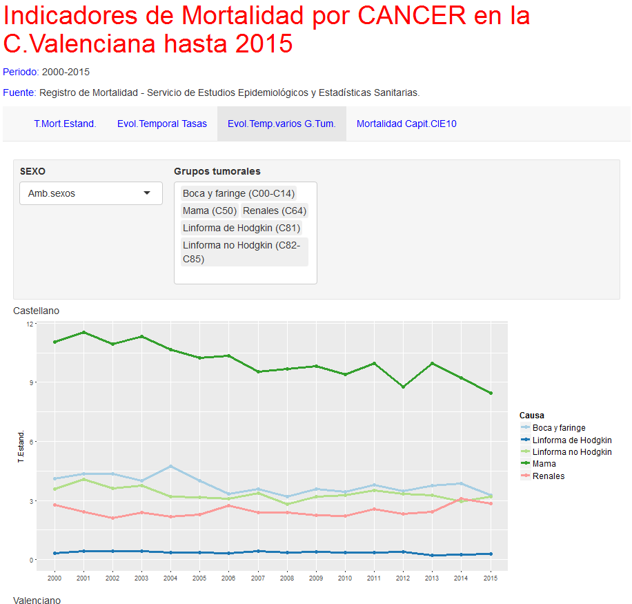

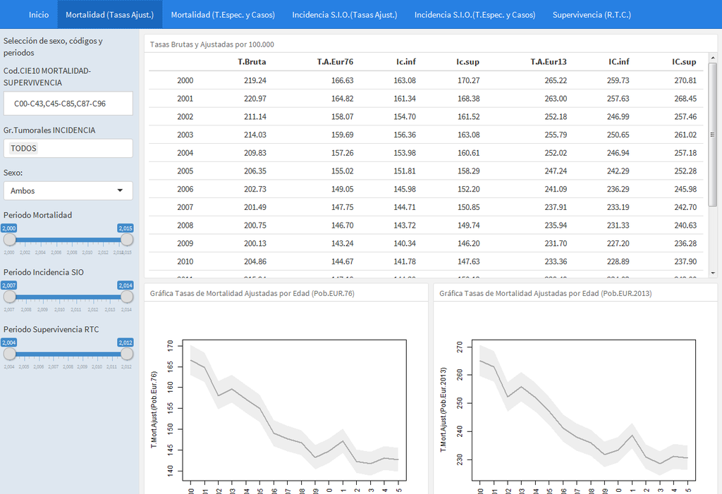

## Introducción

### Documentos interactivos en RMarkdown

Existen dos posibles formas de crear un documento interactivo desde RMarkdown:

1. Utilizando elementos de **Shiny** ([R Shiny](https://shiny.rstudio.com/)): *En esta sesión introduciremos los elementos básicos*.
2. Incorporando **gráficos y/o tablas interactivas**, también conocidos como *htmlwidgets* ([htmlwidgetsR](http://www.htmlwidgets.org/)) que existen en diferentes librerías de R: *Se presentarán en las próximas sesiones como elementos que complementan muy bien con Shiny*.

**Ambas formas pueden combinarse**

## Introducción

### Shiny

Shiny es un **paquete** de RStudio que permite construir de manera muy fácil aplicaciones web interactivas con R.

https://shiny.rstudio.com/

[figure not shown]

## Documentos interactivos

## Documentos interactivos

Los **documentos interactivos** que vamos a introducir en esta sesión son **documentos** creados con **R Markdown** que permiten al lector/usuario, a través de **interactuar** con algunos objetos insertados en el mismo, visualizar diferentes resultados numéricos o gráficos en función de la selección realizada.

Veremos como crear documentos interactivos introduciendo en un documento R Markdown *widgets de Shiny* y *salidas de resultados* vinculadas a los mismos.

## Cómo crear un documento interactivo

### Paso 1

[figure not shown]

## Cómo crear un documento interactivo

### Paso 2

[figure not shown]

## Documento interactivo

### Ejemplo que genera RStudio (1)

[figure not shown]

## Documento interactivo

### Ejemplo que genera RStudio (2)

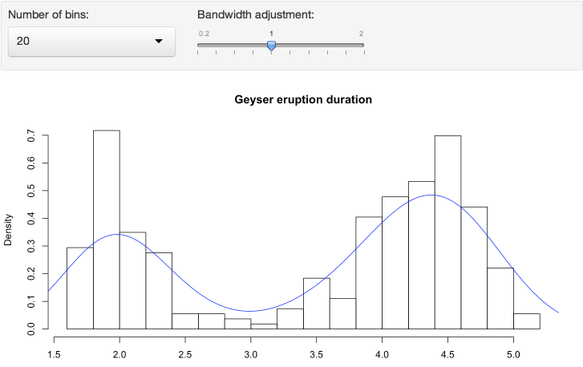

Veamos directamente como funciona…Ejemplo 1

## Documento interactivo

### Ejemplo que genera RStudio (3)

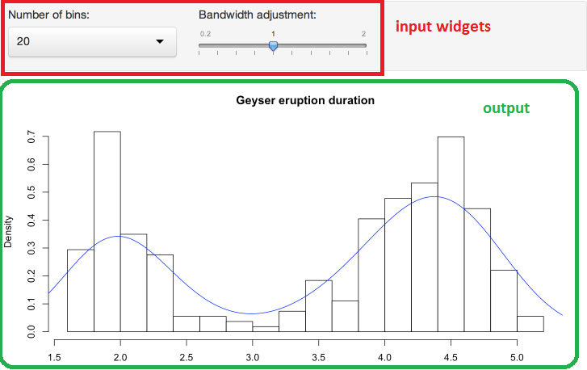

## Documento interactivo

### Ejemplo que genera RStudio (4)

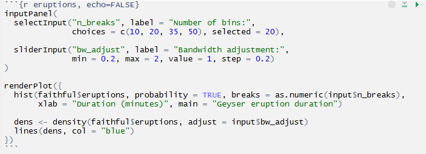

## Documento interactivo

### Ejemplo que genera RStudio (5)

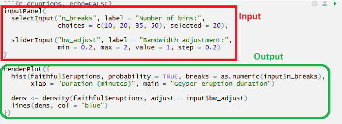

## Documento interactivo

### Ejemplo que genera RStudio (5)

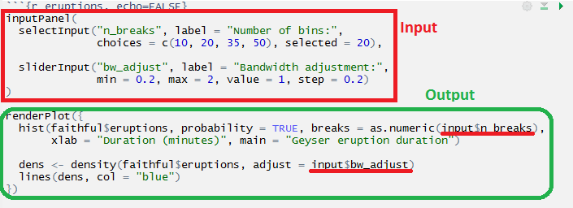

## Widgets: Inputs

## Widgets: Inputs

Se incluyen dentro del panel de *inputs*: *inputPanel{…}*

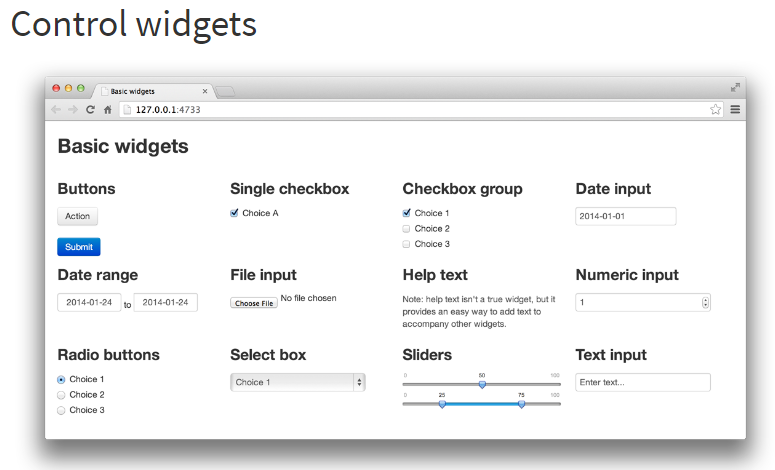

## Inputs: numericInput

- Permite introducir únicamente valores númericos (si intentamos introducir cualquier otro símbolo tomará el valor `NA`)
- Permite teclear el número (con o sin decimales), aunque dispone de un selector que podemos utilizar.
- Su valor será el número introducido, en su defecto `NA`

## Inputs: numericInput (*Sintaxis*)

```r
numericInput(inputId, label, value, min = NA, max = NA, step = NA,width = NULL)
```

**Arguments**

**`inputId:`** `the slot that will be used to access the value.`

**`label:`** `Display label for the control, or NULL for no label.`

**`value:`** `Initial value.`

**`min:`** `Minimum allowed value`

**`max:`** `Maximum allowed value`

**`step:`** `Interval to use when stepping between min and max`

**`width:`** `The width of the input, e.g. '400px', or '100%'; see validateCssUnit.`

## Inputs: numericInput (*Ejemplo*)

```r
inputPanel(
  numericInput("num", label = "Selecciona un valor", value = NULL,min=2,max=10,step=2)
)

renderPrint({
  input$num
})
```

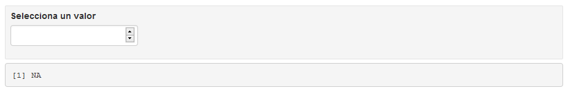

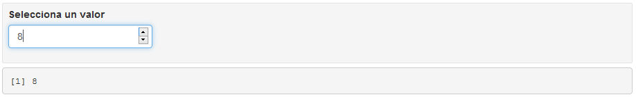

## Inputs: textInput

- Permite introducir cualquier símbolo (numérico, carácter,…)
- Su valor será la cadena de caracteres introducida, en su defecto "".

## Inputs: textInput (*Sintaxis*)

```r
textInput(inputId, label, value = "", width = NULL, placeholder = NULL)
```

**Arguments**

**`placeholder:`** `A character string giving the user a hint as to what can be entered into the control. Internet Explorer 8 and 9 do not support this option.`

Aparece en gris claro el texto que introduzcamos en este parámetro como ayuda al usuario del documento interactivo. Aunque aparece dentro de la caja el valor del input correspondiente es "" mientras no se introduzca cualquier cadena de caracteres

## Inputs: textInput (*Ejemplo 1*)

```r
inputPanel(
  textInput("titulo", label = "Título del gráfico", value = "",placeholder = "Introduce aquí el título"),
  textInput("etiqx",labe="Título del eje x",value=""),
  textInput("etiqy",labe="Título del eje y",value="")
)

renderPrint(input$titulo)

renderPlot({
  plot(1:10,1:10,main=input$titulo,xlab=input$etiqx, ylab=input$etiqy)
})
```

## Inputs: textInput (*Ejemplo 2*)

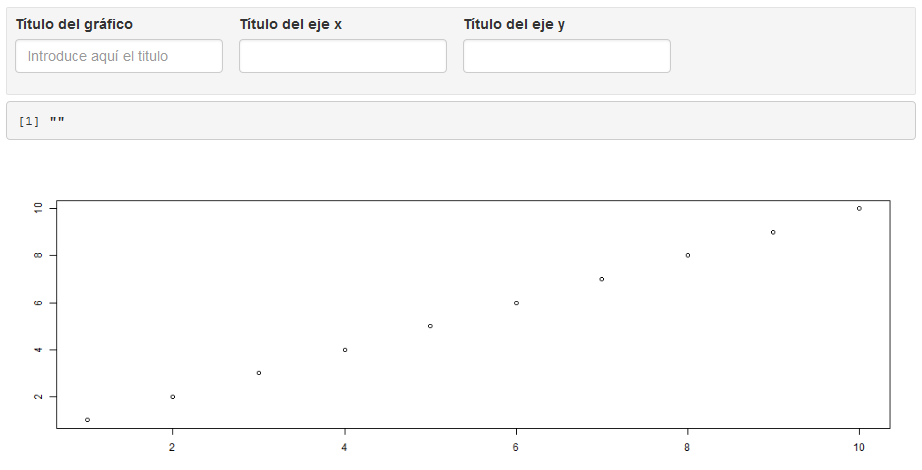

## Inputs: textInput (*Ejemplo 3*)

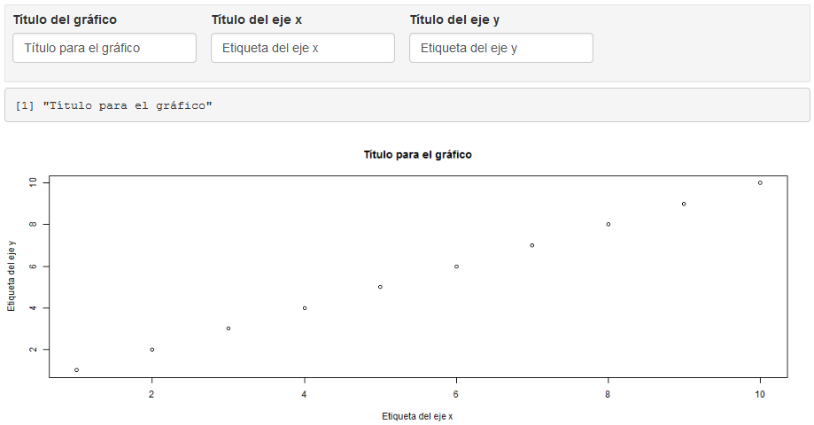

## Inputs: dateInput/dateRangeInput

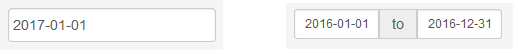

- Permite introducir una fecha, o bien un rango de fechas.
- Ofrece diferentes formatos para la fecha (o fechas) y para la forma de selección y visualización.
- Su valor será la fecha introducida en el *dateInput*, o bien un vector con dos elementos en el caso del *dateRangeInput*.
- Siempre toman un valor, si no se selecciona ninguno tomarán la fecha actual (la del sistema)
- En el caso del *dateRangeInput* no controla que la primera fecha sea menor que la segunda, recoge dos fechas independientes.

## Inputs: dateInput/dateRangeInput (*Sintaxis 1*)

```r
dateInput(inputId, label, value = NULL, min = NULL, max = NULL,
  format = "yyyy-mm-dd", startview = "month", weekstart = 0,
  language = "en", width = NULL)
```

**Arguments**

**`value:`** `The starting date. Either a Date object, or a string in yyyy-mm-dd format. If NULL (the default), will use the current date in the client's time zone.`

**`format:`** `The format of the date to display in the browser. Defaults to "yyyy-mm-dd".`

El valor inicial debemos darlo en el formato que indica, *yyyy-mm-dd*, aunque en función de los parámetros que veremos a continuación se visualizará de una forma u otra. Por ejemplo, podemos seleccionar ver las fechas de la siguiente forma *format="dd/mm/yyyy"*. Se puede profundicar en el parámetro *format* en la ayuda del control (visualizar el número de mes o el nombre, etc,…)

## Inputs: dateInput/dateRangeInput (*Sintaxis 2*)

```r
dateInput(inputId, label, value = NULL, min = NULL, max = NULL,
  format = "yyyy-mm-dd", startview = "month", weekstart = 0,
  language = "en", width = NULL)
```

**Arguments**

**`min`**: `The minimum allowed date. Either a Date object, or a string in yyyy-mm-dd format.`

**`max`**: `The maximum allowed date. Either a Date object, or a string in yyyy-mm-dd format.`

Este control ofrece una ventana *calendario* para seleccionar la fecha deseada. Esta fecha mínima y máxima refleja las fechas que se pueden seleccionar en ese calendario. En ese calendario únicamente nos permitirá seleccionar fechas que se encuentren en el rango definido. Sin embargo, tecleando manualmente el control permite recoger cualquier fecha, incluso fuera del rango que indicamos en *min* y *max*.

## Inputs: dateInput/dateRangeInput (*Sintaxis 3*)

```r
dateInput(inputId, label, value = NULL, min = NULL, max = NULL,
  format = "yyyy-mm-dd", startview = "month", weekstart = 0,
  language = "en", width = NULL)
```

**`startview`**: `The date range shown when the input object is first clicked. Can be "month" (the default), "year", or "decade".`

En este parámetro se recoge únicamente la configuración del objeto calendario que se despliega para que podamos seleccionar en él una fecha. Por defecto aparece un mes (el de la fecha que contiene *value* o el actual en otro caso), aunque podemos querer ver los meses del año en cuestión o bien los años de la década, y así ir seleccionando año y mes hasta visualizar los días del mes.

## Inputs: dateInput/dateRangeInput (*Sintaxis 4*)

```r
dateInput(inputId, label, value = NULL, min = NULL, max = NULL,
  format = "yyyy-mm-dd", startview = "month", weekstart = 0,
  language = "en", width = NULL)
```

**Arguments**

**`weekstart`**: `Which day is the start of the week. Should be an integer from 0 (Sunday) to 6 (Saturday).`

Podemos elegir `weekstart=1` si queremos visualizar las semanas comenzando en el lunes.

**`language`**: `The language used for month and day names. Default is *"en"*. Other valid values include *"es", "ca", ...`.

Elegiremos `language="es"` si queremos ver los nombres de los días y meses en español.

## Inputs: dateInput/dateRangeInput (*Ejemplo 1*)

```r
inputPanel(dateInput("Fecha", label = "Fecha de ingreso",
                     value="2017-06-07",format="dd/mm/yyyy",
                     language="es",weekstart = 1,
                     min="2017-06-01",max="2017-06-15")
)

renderPrint({ input$Fecha })

inputPanel(
dateRangeInput("FechaDesdeHasta", label = "Fecha desde hasta",start="2016-01-01",end="2016-12-31")
)

renderPrint({input$FechaDesdeHasta })
```

## Inputs: dateInput/dateRangeInput (*Ejemplo 2*)

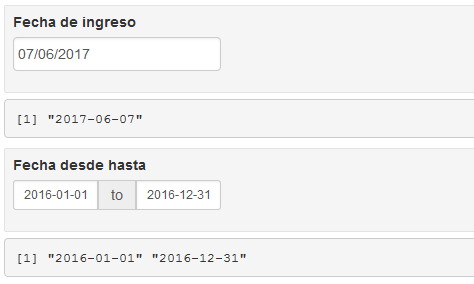

## Inputs: dateInput/dateRangeInput (*Ejemplo 3*)

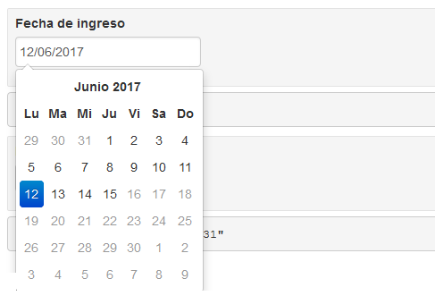

## Inputs: selectInput

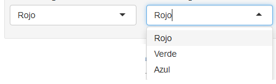

- Permite seleccionar únicamente valores definidos en el control
- Si intentamos introducir cualquier otro símbolo seleccionará el que tiene definido por defecto o el primero.
- Según se configure con los parámetros permitirá seleccionar un único valor o varios, y en este último caso su valor será un vector.

## Inputs: selectInput (*Sintaxis 1*)

```r
selectInput(inputId, label, choices, selected = NULL, multiple = FALSE,
  selectize = TRUE, width = NULL, size = NULL)
```

**Arguments**

**`choices`**: `List of values to select from. If elements of the list are named then that name rather than the value is displayed to the user.`

Este parámetro recoge tanto las opciones que queremos que se puedan seleccionar como los valores que se guardarán internamente si son seleccionadas.

## Inputs: selectInput (*Sintaxis 2*)

```r
selectInput(inputId, label, choices, selected = NULL, multiple = FALSE,
  selectize = TRUE, width = NULL, size = NULL)
```

**Arguments**

**`selected`**: `The initially selected value (or multiple values if multiple = TRUE). If not specified then defaults to the first value for single-select lists and no values for multiple select lists.`

En el parámetro `selected` se seleccionará, de las opciones posibles, la que estará marcada por defecto. Si no se indica esta opción, o en este parámetro se proporciona un valor no posible se seleccionará por defecto la primera de las opciones.

## Inputs: selectInput (*Sintaxis 3*)

```r
selectInput(inputId, label, choices, selected = NULL, multiple = FALSE,
  selectize = TRUE, width = NULL, size = NULL)
```

**Arguments**

**`multiple`**: `Is selection of multiple items allowed?`

Parámetro que recoge si permitimos selección de varios ítems (*multiple=TRUE*) o de un único ítem (*multiple=FALSE*). Si permitimos selección múltiple se recogerá un vector con todas las opciones.

## Inputs: selectInput (*Ejemplo 1*)

```r
inputPanel(
  selectInput("ColorSel1", label = "Color del gráfico 1",
      choices = list("Rojo" = 1, "Verde" = 2, "Azul" = 3),
      selected = 1,multiple=TRUE),
  selectInput("ColorSel2",label="Color del gráfico 2",
      choices=list("Rojo"="red","Verde"="green","Azul"="blue"),
      selected="Rojo")
)

renderPrint(input$ColorSel1)

renderPrint(input$ColorSel2)

renderPlot({
  par(mfrow=c(1,2))
  plot(density(rnorm(1000,0,1)),col=as.numeric(input$ColorSel1)+1,xlab="",ylab="",main="Gráfico 1")
  plot(density(rnorm(1000,0,1)),col=input$ColorSel2,xlab="",ylab="",main="Gráfico 2")
})
```

## Inputs: selectInput (*Ejemplo 2*)

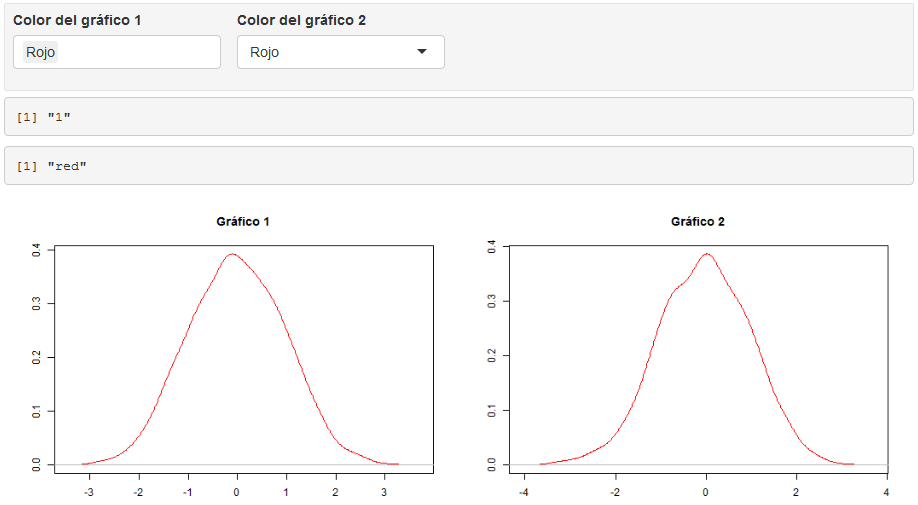

## Inputs: selectInput (*Ejemplo 3*)

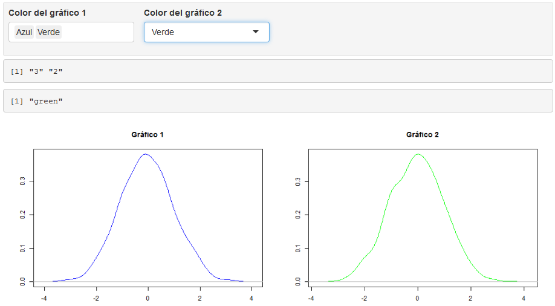

## Inputs: radioButtons

- Permite seleccionar **una** de las opciones definidas en el control.
- Si se quiere dar la posibilidad de "no marcar" ninguna, la mejor forma es incluir una opción *Ninguna*

## Inputs: radioButtons (*Sintaxis 1*)

```r
radioButtons(inputId, label, choices, selected = NULL, inline = FALSE,
  width = NULL)
```

**Arguments**

**`choices`**: `List of values to select from (if elements of the list are named then that name rather than the value is displayed to the user)`

**`selected`**: `The initially selected value (if not specified then defaults to the first value)`

**`inline`**: `If TRUE, render the choices inline (i.e. horizontally)`

Las opciones *choices* y *selected* tienen el mismo comportamiento que en el control *selectInput*. La opción *inline* permite ordenar las opciones de forma vertical (por defecto) o de forma horizontal.

## Inputs: radioButtons (*Ejemplo 1*)

```r
inputPanel(
  radioButtons("radio1", label = "Selecciona una opción",
      choices = list("Rojo" = 1, "Verde" = 2, "Azul" = 3),
      selected = 1),
  radioButtons("radio2", label = "Selecciona una opción",
      choices = list("Rojo" = "red", "Verde" = "green", "Azul" = "blue"),
      selected = "red")
)
renderPlot({
  par(mfrow=c(1,2))
  plot(density(rnorm(1000,0,1)),col=as.numeric(input$radio1)+1,xlab="",ylab="",main="")
  plot(density(rnorm(1000,0,1)),col=input$radio2,xlab="",ylab="",main="")
})
```

## Inputs: radioButtons (*Ejemplo 2*)

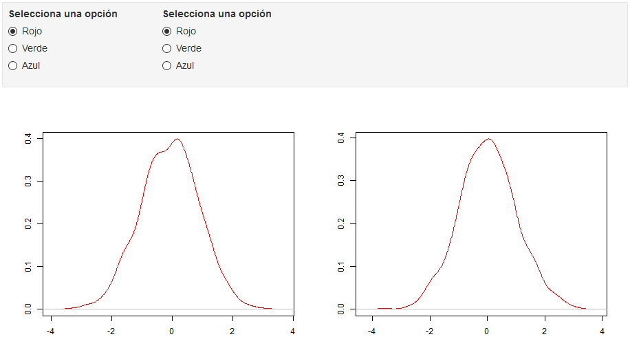

## Inputs: radioButtons (*Ejemplo 3*)

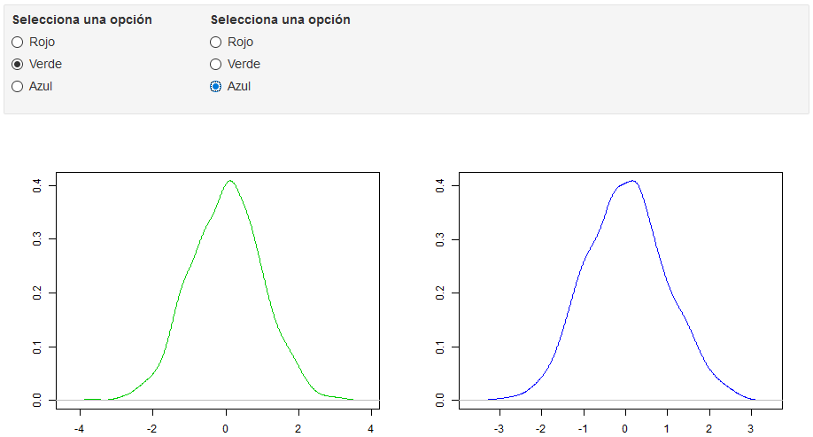

## Inputs: checkboxInput

- Permite marcar o no una opción propuesta.
- Toma el valor `FALSE` si la opción no ha sido marcada y el valor `TRUE` si la opción sí ha sido marcada. Por defecto podemos incluir si en un inicio queremos que esté marcada o no (parámetro `value`).

**Arguments**

```r
checkboxInput(inputId, label, value = FALSE, width = NULL)
```

## Inputs: checkboxInput (*Ejemplo 1*)

```r
x1<-rnorm(100)

inputPanel(
    checkboxInput("CB1","Representa densidad en histograma")
  )

renderPlot({
  hist(x1,col="red",probability=TRUE,main="Histograma")
  if (input$CB1){
    lines(density(x1),col="blue",lwd=2)
  }
})
```

## Inputs: checkboxInput (*Ejemplo 2*)

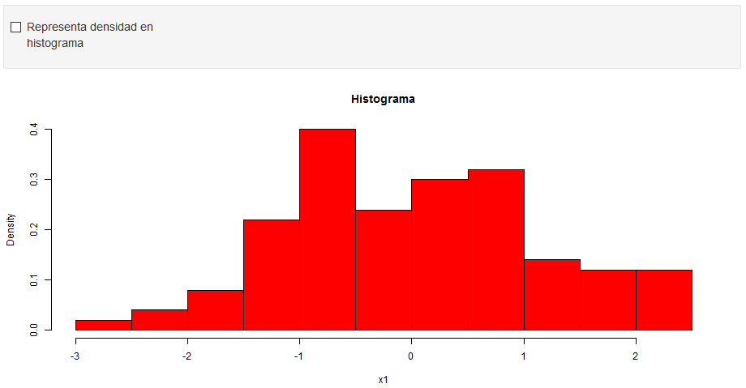

## Inputs: checkboxInput (*Ejemplo 3*)

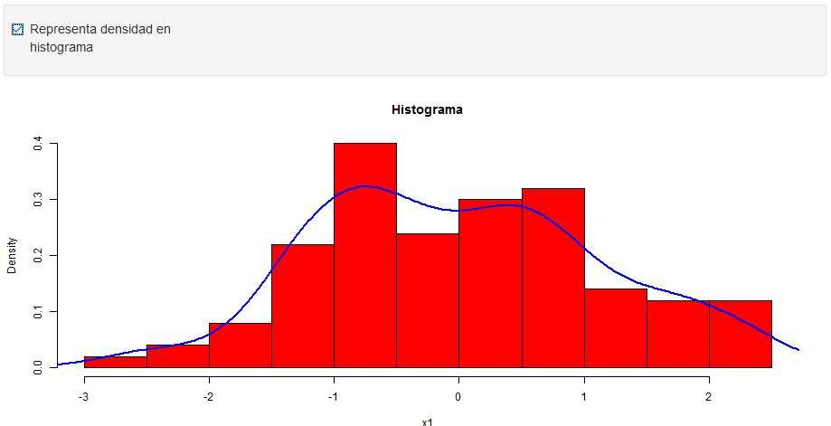

## Inputs: checkboxGroupInput

- Permite marcar varias de las opciones propuestas.
- Su valor es un vector con tantos elementos como opciones seleccionadas. Cada uno de esos elementos toma el valor que en la configuración se haya definido para cada opción.
- En caso de no seleccionar ninguna opción toma el valor `NULL`.

## Inputs: checkboxGroupInput (*Sintaxis*)

```r
checkboxGroupInput(inputId, label, choices, selected = NULL, inline = FALSE,
  width = NULL)
```

**Arguments**

**`choices`**: `List of values to show checkboxes for. If elements of the list are named then that name rather than the value is displayed to the user`

**`selected`**: `The values that should be initially selected, if any`.

**`inline`**: `If TRUE, render the choices inline (i.e. horizontally)`

## Inputs: checkboxGroupInput (*Ejemplo 1*)

```r
x21<-rnorm(10000,0,1)
x22<-rnorm(10000,0,2)
x23<-rnorm(10000,0,3)
x2<-data.frame(x21,x22,x23)
colnames(x2)<-c("DV1","DV2","DV3")

inputPanel(
checkboxGroupInput("CBvariables", "Variables Normales:",
                   c("DT = 1" = "DV1","DT = 2" = "DV2","DT = 3" = "DV3"),
                   selected="DV1")
  )

renderPrint(
  input$CBvariables
)

renderPlot({
  if(is.null(input$CBvariables))     return(NULL)
  plot(1,1,type="n",xlim=c(-10,10),ylim=c(0,0.4))
  for (i in 1:length(input$CBvariables)){
    lines(density(x2[,input$CBvariables[i]]),type="l",col=i)
  }
})
```

## Inputs: checkboxGroupInput (*Ejemplo 2*)

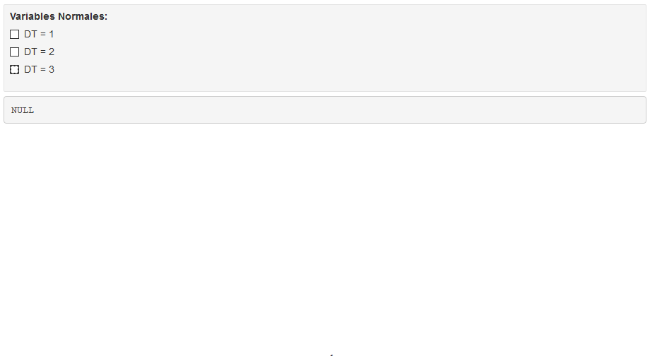

## Inputs: checkboxGroupInput (*Ejemplo 2*)

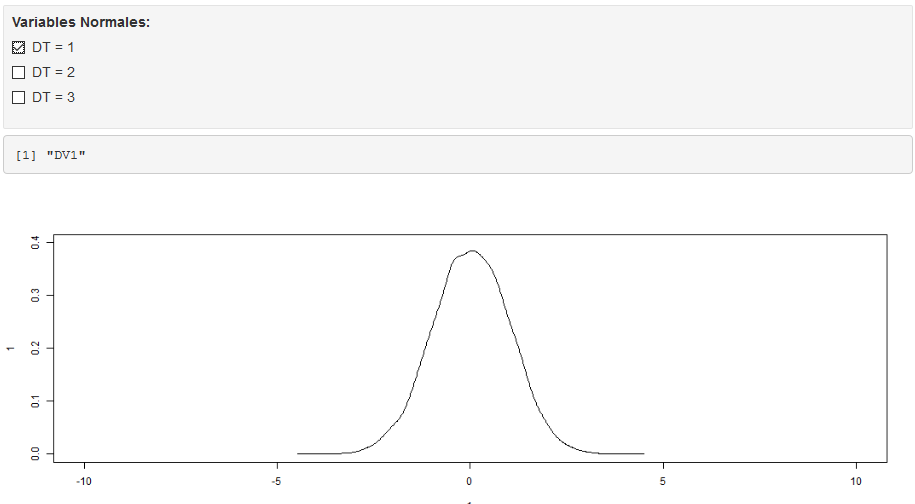

## Inputs > checkboxGroupInput (Ejemplo 3)

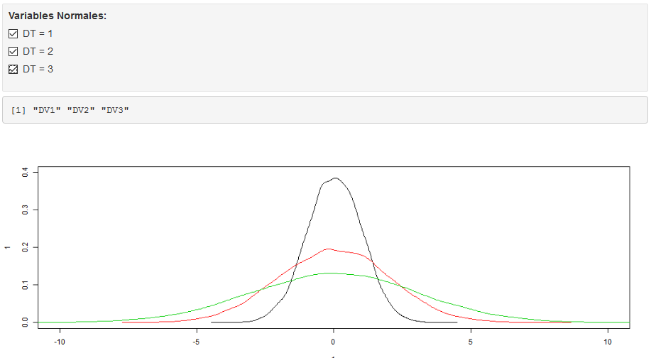

## Inputs: actionButton

- Ejecuta una acción tras ser pulsado por el usuario.
- Toma el valor *0* por defecto, y va incrementando su valor en una unidad cada vez que es pulsado.

## Inputs: actionButton (*Sintaxis*)

```r
actionButton(inputId, label, icon = NULL, width = NULL, ...)
```

**Arguments**

**`icon`**: `An optional icon to appear on the button.`

Permite añadir un icono al botón.

## Inputs: actionButton (*Ejemplo 1*)

```r
inputPanel(
    actionButton("Ejecuta","Pulsa para visualizar histograma")
  )

renderPrint(
  input$Ejecuta
)
renderPlot({
  if (input$Ejecuta){
    hist(rnorm(100),col="red",main="Histograma")
  }
})
```